# Data manipulations

```r
print(iqr_low)
```

```
##   25%
## 114.5
```

```r
print(iqr_high)
```

```
##   75%
## 294.5
```

Continue on with the NASCET score (how much smaller is the lumen of the ICA?) shapiro-Wilk:

```r
shapiro.test(part1$ICAE_NASCET_Degree) # w=0.61, p=2.2e-16
```

```
##
##  Shapiro-Wilk normality test
##
## data:  part1$ICAE_NASCET_Degree
## W = 0.61801, p-value < 2.2e-16
```

Histogram:

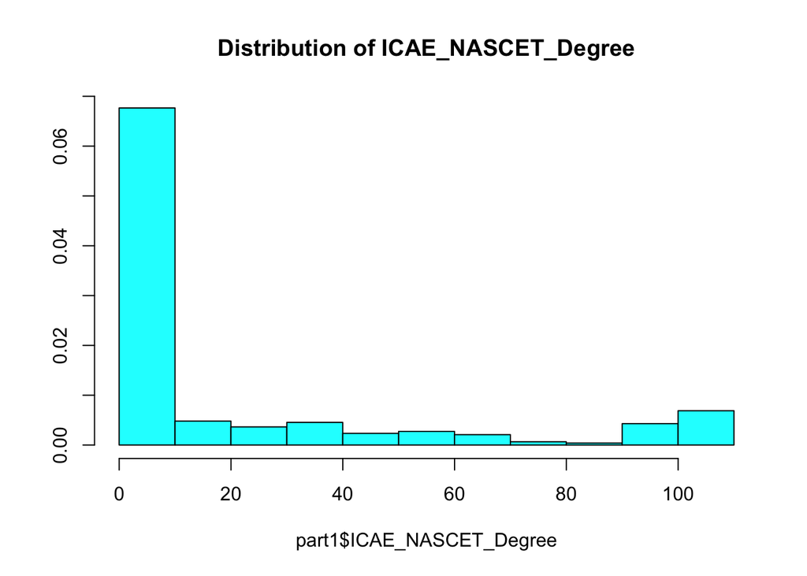

```r
par(mfrow=c(1,1))
truehist(part1$ICAE_NASCET_Degree, main = "Distribution of ICAE_NASCET_Degree" )
```

QQ plot:

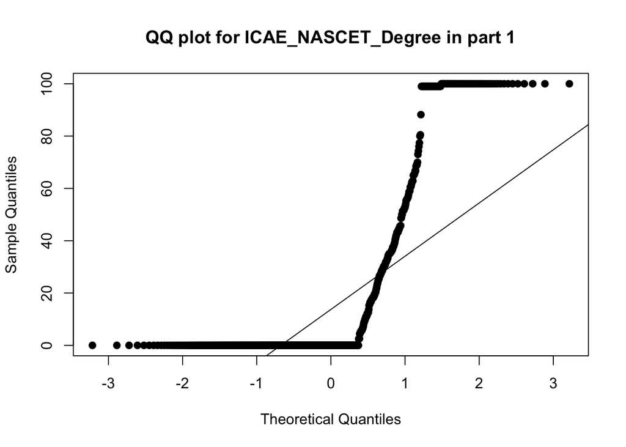

```r
qqnorm(part1$ICAE_NASCET_Degree, main = "QQ plot for ICAE_NASCET_Degree in part 1", pch=19)
qqline(part1$ICAE_NASCET_Degree)
```

Other vascular anatomical variables were factors and hence the total number with percentage was calculated: Aortic variant, A, B, C

```r
total.1 <- summary(part1$AorticVariant)[1]+summary(part1$AorticVariant)[4]
percentage <- ((summary(part1$AorticVariant)[1])/887)*100
print(total.1,0) # A+D
```

```
## Type A
##    654
```

```r
print(percentage,0)
```

```
## Type A
##     70
```

```r
total.2 <- summary(part1$AorticVariant)[2]
percentage <- ((summary(part1$AorticVariant)[2])/887)*100
print(total.2,0) # B
```

```
## Type B
##    123
```

```r
print(percentage,0)
```

```
## Type B
##     14
```

```r
total.3 <- summary(part1$AorticVariant)[3]
percentage <- ((summary(part1$AorticVariant)[3])/887)*100
print(total.3,0) # C
```

```
## Type C
##    105
```

```r
print(percentage,0)
```

```
## Type C
##     12
```

Arch elongation, I, II, III

```r
total.1 <- summary(part1$ArchElongation)[1]
percentage <- ((summary(part1$ArchElongation)[1])/887)*100
print(total.1,0) # A+D
```

```
##   I
## 155
```

```r
print(percentage,0)
```

```
##  I
## 17
```

```r
total.2 <- summary(part1$ArchElongation)[2]
percentage <- ((summary(part1$ArchElongation)[2])/887)*100
print(total.2,0) # B
```

```
##  II
## 561
```

```r
print(percentage,0)
```

```
## II
## 63
```

```r
total.3 <- summary(part1$ArchElongation)[3]
percentage <- ((summary(part1$ArchElongation)[3])/887)*100
print(total.3,0) # C
```

```
## III
## 169
```

```r
print(percentage,0)
```

```
## III
##  19
```

Inn origin atherosclerosis, not present, yes, both, not applicable

```r
total.1 <- summary(part1$InnAtherosclerosis)[1]
percentage <- ((summary(part1$InnAtherosclerosis)[1])/887)*100
print(total.1,0) # not present
```

```
##  no
## 224
```

```r
print(percentage,0)
```

```
## no
## 25
```

```r
total.2 <- summary(part1$InnAtherosclerosis)[2]
percentage <- ((summary(part1$InnAtherosclerosis)[2])/887)*100
print(total.2,0) # yes
```

```
## Yes, calcified spots
##                   72
```

```r
print(percentage,0)
```

```
## Yes, calcified spots
##                    8
```

```r
total.3 <- summary(part1$InnAtherosclerosis)[3]
percentage <- ((summary(part1$InnAtherosclerosis)[3])/887)*100
print(total.3,0) # both
```

```
## Not applicable
##            414
```

```r
print(percentage,0)
```

```
## Not applicable
##             47
```

```r
total.4 <- summary(part1$InnAtherosclerosis)[4]
percentage <- ((summary(part1$InnAtherosclerosis)[4])/887)*100
print(total.4,0) # not applicable
```

```
## Yes, stenosis
##           128
```

```r
print(percentage,0)
```

```
## Yes, stenosis
##            14
```

CCA origin atherosclerosis, not present, yes, both, not applicable

```r
total.1 <- summary(part1$CCAOrigin)[1]
percentage <- ((summary(part1$CCAOrigin)[1])/887)*100
print(total.1,0) # not present
```

```
## No
## 64
```

```r
print(percentage,0)
```

```
## No
##  7
```

```r
total.2 <- summary(part1$CCAOrigin)[2]
percentage <- ((summary(part1$CCAOrigin)[2])/887)*100
print(total.2,0) # yes
```

```
## Yes
## 130
```

```r
print(percentage,0)
```

```
## Yes
##  15
```

```r
total.3 <- summary(part1$CCAOrigin)[3]
percentage <- ((summary(part1$CCAOrigin)[3])/887)*100
print(total.3,0) # both
```

```
## Both
##   59
```

```r
print(percentage,0)
```

```
## Both
##    7
```

```r
total.4 <- summary(part1$CCAOrigin)[4]
percentage <- ((summary(part1$CCAOrigin)[4])/887)*100
print(total.4,0) # not applicable
```

```
## Not applicable
##            552
```

```r
print(percentage,0)
```

```
## Not applicable
##             62
```

Inn origin atherosclerosis, not present, yes, both, not applicable

```r
total.1 <- summary(part1$InnOrigin)[1]
percentage <- ((summary(part1$InnOrigin)[1])/887)*100
print(total.1,0) # not present
```

```
## No
## 18
```

```r
print(percentage,0)
```

```
## No
##  2
```

```r
total.2 <- summary(part1$InnOrigin)[2]
percentage <- ((summary(part1$InnOrigin)[2])/887)*100
print(total.2,0) # yes
```

```
## Yes
## 131
```

```r
print(percentage,0)
```

```
## Yes
##  15
```

```r
total.3 <- summary(part1$InnOrigin)[3]
percentage <- ((summary(part1$InnOrigin)[3])/887)*100
print(total.3,0) # both
```

```
## Both
##   51
```

```r
print(percentage,0)
```

```
## Both
##    6
```

```r
total.4 <- summary(part1$InnOrigin)[4]
percentage <- ((summary(part1$InnOrigin)[4])/887)*100
print(total.4,0) # not applicable
```

```
## Not applicable
##            638
```

```r
print(percentage,0)
```

```
## Not applicable
##             72
```

CCA atherosclerosis, not present, yes spots, yes<50, yes>50

```r
summary(part1$CcaAherosclerosis)
```

```
##                   No Yes, calcified spots   Yes, <50% stenosis
##                  552                   95                  146
##  Yes, >=50% stenosis                 NA's
##                   12                   82
```

```r
total.1 <- summary(part1$CcaAherosclerosis)[1]
percentage <- ((summary(part1$CcaAherosclerosis)[1])/887)*100
print(total.1,0) # not present
```

```
##  No
## 552
```

```r
print(percentage,0)
```

```
## No
## 62
```

```r
total.2 <- summary(part1$CcaAherosclerosis)[2]
percentage <- ((summary(part1$CcaAherosclerosis)[2])/887)*100
print(total.2,0) # yes spots
```

```
## Yes, calcified spots
##                   95
```

```r
print(percentage,0)
```

```
## Yes, calcified spots
##                   11
```

```r
total.3 <- summary(part1$CcaAherosclerosis)[3]
percentage <- ((summary(part1$CcaAherosclerosis)[3])/887)*100
print(total.3,0) # yes <50
```

```
## Yes, <50% stenosis
##                146
```

```r
print(percentage,0)
```

```
## Yes, <50% stenosis
##                 16
```

```r
total.4 <- summary(part1$CcaAherosclerosis)[4]
percentage <- ((summary(part1$CcaAherosclerosis)[4])/887)*100
print(total.4,0) # yes >50
```

```
## Yes, >=50% stenosis
##                  12
```

```r
print(percentage,0)
```

```
## Yes, >=50% stenosis
##                   1
```

Number of 90 angles in Inn + CCA, 0, 1, 2, >3

```r
total.1 <- summary(part1$InnCca_nr_90orLarger)[1]
percentage <- ((summary(part1$InnCca_nr_90orLarger)[1])/887)*100
print(total.1,0) # 0 angles
```

```
##   0
## 521
```

```r
print(percentage,0)
```

```
##  0
## 59
```

```r
total.2 <- summary(part1$InnCca_nr_90orLarger)[2]
percentage <- ((summary(part1$InnCca_nr_90orLarger)[2])/887)*100
print(total.2,0) # 1 angle
```

```
##   1
## 213
```

```r
print(percentage,0)
```

```
##  1
## 24
```

```r
total.3 <- summary(part1$InnCca_nr_90orLarger)[3]
percentage <- ((summary(part1$InnCca_nr_90orLarger)[3])/887)*100
print(total.3,0) # 2 angles
```

```
##   2
## 104
```

```r
print(percentage,0)
```

```
##  2
## 12
```

```r
total.4 <- summary(part1$InnCca_nr_90orLarger)[4]
percentage <- ((summary(part1$InnCca_nr_90orLarger)[4])/887)*100
print(total.4,0) # 3 angles
```

```
##  3
## 21
```

```r
print(percentage,0)
```

```
## 3
## 2
```

Number of 90 angles in ICA, 0, 1, 2, >3

```r
total.1 <- summary(part1$ICA_nr_90orLarger)[1]
percentage <- ((summary(part1$ICA_nr_90orLarger)[1])/887)*100
print(total.1,0) # 0 angles
```

```
## Min.
##    1
```

```r
print(percentage,0)
```

```
## Min.
##    0
```

```r
total.2 <- summary(part1$ICA_nr_90orLarger)[2]
percentage <- ((summary(part1$ICA_nr_90orLarger)[2])/887)*100
print(total.2,0) # 1 angle
```

```
## 1st Qu.
##       1
```

```r
print(percentage,0)
```

```
## 1st Qu.
##       0
```

```r
total.2 <- summary(part1$ICA_nr_90orLarger)[3]
percentage <- ((summary(part1$ICA_nr_90orLarger)[3])/887)*100
print(total.2,0) # 1 angle
```

```
## Median
##      2
```

```r
print(percentage,0)
```

```
## Median
##      0
```

```r
total.3 <- summary(part1$ICA_nr_90orLarger)[4]+summary(part1$ICA_nr_90orLarger)[5]+summary(part1$ICA_nr_90orLarger)[6]
percentage <- (total.3/887)*100
print(total.3,0) # 2 angles
```

```
## Mean
##   11
```

```r
print(percentage,0)
```

```
## Mean
##    1
```

ICAI atherosclerosis, not present, yes spots, yes<50, yes>50

```r
total.1 <- summary(part1$ICAIAtherosclerosis)[1]
percentage <- ((summary(part1$ICAIAtherosclerosis)[1])/887)*100
print(total.1,0) # not present
```

```
##  No
## 190
```

```r
print(percentage,0)
```

```
## No
## 21
```

```r
total.2 <- summary(part1$ICAIAtherosclerosis)[2]
percentage <- ((summary(part1$ICAIAtherosclerosis)[2])/887)*100
print(total.2,0) # yes spots
```

```
## Yes, calcified spots
##                  162
```

```r
print(percentage,0)
```

```
## Yes, calcified spots
##                   18
```

```r
total.3 <- summary(part1$ICAIAtherosclerosis)[3]
percentage <- ((summary(part1$ICAIAtherosclerosis)[3])/887)*100
print(total.3,0) # yes<50
```

```
## Yes, <50% stenosis
##                202
```

```r
print(percentage,0)
```

```
## Yes, <50% stenosis
##                 23
```

```r
total.4 <- summary(part1$ICAIAtherosclerosis)[4]
percentage <- ((summary(part1$ICAIAtherosclerosis)[4])/887)*100
print(total.4,0) # yes>50
```

```
## Yes, >=50% stenosis
##                 111
```

```r
print(percentage,0)
```

```
## Yes, >=50% stenosis
##                  13
```

ICAI stenosis, <50, >50

```r
total.1 <- summary(part1$ICAI_stenosis50)[1]
percentage <- ((summary(part1$ICAI_stenosis50)[1])/887)*100
print(total.1,0) # <50
```

```
## Stenosis < 50%
##            554
```

```r
print(percentage,0)
```

```
## Stenosis < 50%
##             62
```

```r
total.2 <- summary(part1$ICAI_stenosis50)[2]
percentage <- ((summary(part1$ICAI_stenosis50)[2])/887)*100
print(total.2,0) # >50
```

```
## Stenose >=50%
##           111
```

```r
print(percentage,0)
```

```
## Stenose >=50%
##            13
```

ICAE atherosclerosis, not present, yes calcified spots, yes stenosis

```r
total.1 <- summary(part1$ICAEAtherosclerosis)[1]
percentage <- ((summary(part1$ICAEAtherosclerosis)[1])/887)*100
print(total.1,0) # not present
```

```
##  No
## 238
```

```r
print(percentage,0)
```

```
## No
## 27
```

```r
total.2 <- summary(part1$ICAEAtherosclerosis)[2]
percentage <- ((summary(part1$ICAEAtherosclerosis)[2])/887)*100
print(total.2,0) # yes calcified spots
```

```
## Yes, calcified spots
##                   99
```

```r
print(percentage,0)
```

```
## Yes, calcified spots
##                   11
```

```r
total.3 <- summary(part1$ICAEAtherosclerosis)[3]
percentage <- ((summary(part1$ICAEAtherosclerosis)[3])/887)*100
print(total.3,0) # yes stenosis
```

```
## Yes, stenosis
##           478
```

```r
print(percentage,0)
```

```
## Yes, stenosis
##            54
```

Origostenosis, not at origin, at origin

```r
total.1 <- summary(part1$OrigoStenosis50percent)[1]
percentage <- ((summary(part1$OrigoStenosis50percent)[1])/887)*100
print(total.1,0) # 0 angles
```

```
## stenosis < 50% or not at origin
##                             787
```

```r
print(percentage,0)
```

```
## stenosis < 50% or not at origin
##                              89
```

```r
total.2 <- summary(part1$OrigoStenosis50percent)[2]
percentage <- ((summary(part1$OrigoStenosis50percent)[2])/887)*100
print(total.2,0) # 0 angles
```

```
## stenosis at origin >=50%
##                       14
```

```r
print(percentage,0)
```

```
## stenosis at origin >=50%
##                        2
```

Aortic variant A+B, C

```r
total.AB<- (summary(part1$AorticVariant)[1])+(summary(part1$AorticVariant)[2])+(summary(part1$AorticVariant)[4]) # variant A, B and D
percentage <- (total.AB/887)*100
print(total.AB,0)
```

```
## Type A
##    777
```

```r
print(percentage,0)
```

```
## Type A
##     88
```

```r
total.C<- summary(part1$AorticVariant)[3] # variant C
percentage <- (total.C/887)*100
print(total.C,0)
```

```
## Type C
##    105
```

```r
print(percentage,0)
```

```
## Type C
##     12
```

Arch elongation type I+II, III

```r
total.I<- (summary(part1$ArchElongation)[1])+(summary(part1$ArchElongation)[2]) # Type I and II
percentage <- (total.I/887)*100
print(total.I,0)
```

```
##   I
## 716
```

```r
print(percentage,0)
```

```
##  I
## 81
```

```r
total.III<- summary(part1$ArchElongation)[3] # variant C
percentage <- (total.III/887)*100
print(total.III,0)
```

```
## III
## 169
```

```r
print(percentage,0)
```

```
## III
##  19
```

Angle <45 AA and Inn or AA and CCA, Yes , No

```r
total.1 <- summary(part1$AngleAaInn_OR_AaCca_dich45)[2]
percentage <- ((summary(part1$AngleAaInn_OR_AaCca_dich45)[2])/887)*100
print(total.1,0) # 0 angles
```

```
## <= 45 degrees
##            70
```

```r
print(percentage,0)
```

```
## <= 45 degrees
##             8
```

90 angle in the Inn or CCA, Yes, No

```r
total.ang<- (summary(part1$InnCca_90orLarger)[1])
percentage <- (total.ang/887)*100
print(total.ang,0)
```

```
##   1
## 521
```

```r
print(percentage,0)
```

```
##  1
## 59
```

90 angle after carotid bifurcation, Yes, No

```r
total.bif<- (summary(part1$AngleFollowingBifurcation)[2])
percentage <- (total.bif/887)*100
print(total.bif,0)
```

```
## Yes, angle >=90 degrees
##                     125
```

```r
print(percentage,0)
```

```
## Yes, angle >=90 degrees
##                      14
```

90 angle in the ICA, Yes, No

```r
total.1 <- summary(part1$ICA_90orLarger)[2]
percentage <- ((summary(part1$ICA_90orLarger)[2])/887)*100
print(total.1,0) # 0 angles
```

```
##   1
## 378
```

```r
print(percentage,0)
```

```
##  1
## 43
```

NASCET >70, Yes, No

```r
total.nascet<- (summary(part1$ICAE_NASCET_70)[2])
percentage <- (total.nascet/887)*100
print(total.nascet,0)
```

```
##  2
## 94
```

```r
print(percentage,0)
```

```
##  2
## 11
```

These were all the variables for part 1. Same code was repeated for part 2 (code not included here).  
End of variable checks and distribution assessment. The above code is used to produce:

- Table 1
- Table 2